# Impacto do Juro Zero

# 1 Definições Iniciais

```r
library(tidyverse)
library(basedosdados)
library(RSelenium)
library(JavaGD)
library(httr)
library(sidrar)
library(abjutils)
library(MatchIt)
library(brglm)
```

```r
library(ggplot2)
```

# 2 Introdução

Nota: este trabalho é um resumo do TCC [Impacto do programa Juro Zero: redução da informalidade nos municípios catarinenses entre 2012 e 2019.](https://repositorio.ufsc.br/bitstream/handle/123456789/227959/tcc_GabrielBelle.pdf?sequence=1).

O objetivo final é a estimação do impacto médio do programa Juro Zero, eliminando fatores externos, como tendências e outros cofundidores. Para tanto, faz-se necessário:

1. Coletar os dados de interesse;
2. Definir a variável de impacto;
3. Selecionar covariadas de controle;
4. Selecionar o grupo de controle e tratamento;
5. Estimar o impacto médio do programa.

# 3 Coleta de dados

Os dados necessários à variável de impacto necessitam de informações antes e depois do programa.

Já os dados para criação do grupo de controle e para o filtro do grupo de tratamento, via PSM, possuem apenas a necessidade de existência pré-programa. Isto leva a uma maior flexibilidade, pois há disponibilidade para uso do Censo geográfico brasileiro, com última informação disponível para 2010. Sua utilização deve levar a uma maior robustez para o trabalho.

Para os dados do Censo 2010 e da RAIS utilizado a https://basedosdados.org/. Desta forma, pode-se recuperar os dados utilizando uma consulta em SQL.

Ps: Note that I store the output so it doesn’t need to be executed repeatedly, when I was testing my script.

## 3.1 Dados do Censo de 2010

Os dados a serem coletados do censo provém da base mais rica disponível, feito apenas em parcela da população. Como o próprio IBGE divulga o peso de cada indivíduo, referente à população, a extrapolação da amostra é feita de forma direta.

Coletaremos dados sobre tamanho da população, população ocupada que recebe pagamento em dinheiro, o tipo de ocupação do trabalhador (CLT, militar, publico…) e a população economicamente ativa (PEA).

Como a opção pelo MEI é disponível apenas para os solicitantes em maioridade, optou-se para filtrar todas as informações para maioridade.

```r
set_billing_id('impact-juro-zero-sc')
```

```r
query_censo <- 'SELECT sigla_uf, id_municipio,
    SUM(peso_amostral) AS pop,
    SUM(case when (v6036 >= 18)
        then peso_amostral else 0 end) AS pop_maioridade,
    SUM(case when (v0641 = 1 OR v0642 = 1) AND
        v6036 >= 18 then peso_amostral else 0 end) AS ocupado_maioridade_dinheiro,
    SUM(case when (v0648 = 1 AND v6036 >= 18) then peso_amostral else 0 end) AS ocupacao_clt,
    SUM(case when (v0648 = 2 AND v6036 >= 18) then peso_amostral else 0 end) AS ocupacao_militar,
    SUM(case when (v0648 = 3 AND v6036 >= 18) then peso_amostral else 0 end) AS ocupacao_publico,
    SUM(case when (v0648 = 4 AND v6036 >= 18) then peso_amostral else 0 end) AS ocupacao_sem_carteira,
    SUM(case when (v0648 = 5 AND v6036 >= 18) then peso_amostral else 0 end) AS ocupacao_conta_propria,
    SUM(case when (v0648 = 6 AND v6036 >= 18) then peso_amostral else 0 end) AS ocupacao_empregador,
    SUM(case when (v0648 = 7 AND v6036 >= 18) then peso_amostral else 0 end) AS ocupacao_sem_remuneracao,
    SUM(case when (v6036 >= 18) then peso_amostral * v6525 else 0 end) AS massa_salario_maioridade,
    SUM(case when (v6900 = 1 AND v6036 >= 18) then peso_amostral else 0 end) AS pea_maioridade,
    SUM(case when (v6900 = 2 AND v6036 >= 18) then peso_amostral else 0 end) AS fora_pea_maioridade,
    SUM(case when (v6910 = 1 AND v6036 >= 18) then peso_amostral else 0 end) AS ocupada_maioridade,
    SUM(case when (v6910 = 2 AND v6036 >= 18) then peso_amostral else 0 end) AS desocupada_maioridade
FROM `basedosdados.br_ibge_censo_demografico.microdados_pessoa_2010`
WHERE (sigla_uf = "SC" OR sigla_uf = "SP")
GROUP BY sigla_uf, id_municipio'

censo_raw <- read_sql(query_censo)
saveRDS(censo_raw, 'censo_raw.rds')
```

```r
censo_raw <- readRDS('censo_raw.rds')
```

## 3.2 Dados do RAIS

A Relação Anual dos Trabalhadores (RAIS) divulga informações de periodicidade anual que são fornecidades a nível de estabelecimento.

Serão coletados dados de:

1. Quantidade de estabelecimentos negativos em 2008

```r
query_rais_a <- 'SELECT sigla_uf,
id_municipio,
SUM(indicador_rais_negativa) AS rais_negativa,
COUNT(indicador_atividade_ano) AS qtd_total_empresas
FROM `basedosdados.br_me_rais.microdados_estabelecimentos`
WHERE ((sigla_uf = "SC" OR sigla_uf = "SP") AND (ano = 2008))
GROUP BY sigla_uf, id_municipio'

rais_a_raw <- read_sql(query_rais_a)
saveRDS(rais_a_raw, 'rais_a_raw.rds')
```

```r
rais_a_raw <- readRDS('rais_a_raw.rds') %>%
  mutate(id_municipio = id_municipio %>%
           as.character())
```

2. Quantidade de estoque de emprego por CNAE

Os dados serão recuperados para 2011.

```r
query_rais_b <- 'SELECT sigla_uf, id_municipio, SUM(qtde_vinculos_ativos) AS total_estoque,
SUM(CASE WHEN CAST(SUBSTR(cnae_2,1,2) AS INT) < 10 THEN qtde_vinculos_ativos ELSE 0 END) AS agro_extracao,
SUM(CASE WHEN (
    (
        CAST(SUBSTR(cnae_2,1,2) AS INT) BETWEEN 10 AND 33) OR (
            CAST(SUBSTR(cnae_2, 1,2) AS INT) BETWEEN 41 AND 43))
            THEN qtde_vinculos_ativos ELSE 0 END) AS industria_construcao,
SUM(CASE WHEN CAST(SUBSTR(cnae_2,1,2) AS INT) BETWEEN 35 AND 39 THEN qtde_vinculos_ativos ELSE 0 END) AS siup,
SUM(CASE WHEN CAST(SUBSTR(cnae_2, 1, 2) AS INT) BETWEEN 45 AND 47 THEN qtde_vinculos_ativos ELSE 0 END) AS comercio,
SUM(CASE WHEN CAST(SUBSTR(cnae_2,1,2) AS INT) BETWEEN 49 AND 99 THEN qtde_vinculos_ativos ELSE 0 END) AS servico,
FROM `basedosdados.br_me_rais.microdados_estabelecimentos`
WHERE ((sigla_uf = "SC" OR sigla_uf = "SP") AND (ano = 2011))
GROUP BY sigla_uf, id_municipio'

rais_b_raw <- read_sql(query_rais_b)
saveRDS(rais_b_raw, 'rais_b_raw.rds')
```

```r
rais_b_raw <- readRDS('rais_b_raw.rds')  %>%
  mutate(id_municipio = id_municipio %>%
           as.character())
```

3. Quantidade de emprego em 31/12:

O tamanho da empresa indica quantas pessoas trabalham no estabelecimento em 31 de dezembro, contabilizado o dono.

```r
query_rais_c <- "SELECT ano, sigla_uf, id_municipio, SUM(tamanho_estabelecimento) AS empregos_dezembro
FROM `basedosdados.br_me_rais.microdados_estabelecimentos`
WHERE ((sigla_uf = 'SC' OR sigla_uf = 'SP') AND (ano = 2011 OR ano = 2019))
GROUP BY ano, sigla_uf, id_municipio"

rais_c_raw <- read_sql(query_rais_c)
saveRDS(rais_c_raw, 'rais_c_raw.rds')
```

```r
rais_c_raw <- readRDS('rais_c_raw.rds') %>%
  mutate(id_municipio = id_municipio %>%
           as.character())
```

## 3.3 Dados de quantidade de MEI

Já para os dados da quantidade de inscritos no MEI, faz-se necessário sua coleta tanto no ínicio quanto ao fim do período de análise. A fonte dos dados é a [Receita Federal](http://www22.receita.fazenda.gov.br/inscricaomei/private/pages/relatorios/opcoesRelatorio.jsf).

Aqui, o método de coleta será uma raspagem (Web Scrapping with Selenium). Esta técnica consiste em simular o comportamento de um humano utilizando comandos vindos da programação. Isto permite escalagem, caso necessário, para coletar todos os dados disponíveis do sistema.

O pacote escolhido foi o RSelenium.

```r
# Carrega a página como teste
rd <- rsDriver(port = 4444L, browser = c("chrome"), chromever = "105.0.5195.19", phantomver = "2.1.1", verbose = TRUE, check = TRUE)

remDr <- rd[["client"]]

# Acessa a url
remdr$navigate('http://www22.receita.fazenda.gov.br/inscricaomei/private/pages/relatorios/opcoesRelatorio.jsf')

# Navega até a página de interesse
municipio <- remdr$findElements('xpath', '//*[@id="1b"]/ul/li[2]/a')
municipio[[1]]$clickElement()
```

```r
query_dates <- c('30-12-2011', '31-12-2019')
query_ufs <- c('SÃO PAULO', 'SANTA CATARINA')

extracted_values <- tibble(
    date = c(),
    uf = c(),
    dados = c()
)

# Por algum motivo a data é apenas inserida após primeiro click no botão de consulta

campo_calendario <- remdr$findElements('id',
                                       'form:dataPesquisaInputDate')

campo_calendario[[1]]$sendKeysToElement(list('01/01/2010'))

consultar <- remdr$findElements('id', 'form:botaoConsultar')
consultar[[1]]$clickElement()

# Seleciona botão para coleta de todos municípios
todos_municipios <- remdr$findElements(
    'xpath', '//*[@id="form:identificacao_body"]/div[1]/div[2]/div[2]/label')
todos_municipios[[1]]$clickElement()

# Loop para coleta dos dados
Sys.sleep(0.1)
for (dt in query_dates) {

    for (estado in query_ufs) {
        print(paste(dt, estado))

         # Insere a data
        campo_calendario <- remdr$findElements('id',
                                               'form:dataPesquisaInputDate')
        campo_calendario[[1]]$sendKeysToElement(list(dt))

        # Coleta as UFs disponíveis
        form_uf <- remdr$findElements('id', 'form:uf')
        form_uf_options <- form_uf[[1]]$findChildElements('tag name', "option")

        # Seleciona a UF correta
        for (i in c(1:length(form_uf_options))) {
            if (form_uf_options[[i]]$getElementText() == estado) {

                form_uf_options[[i]]$clickElement()

            } else {next}
        }

        # Clica em consultar para gerar a tabela
        consultar <- remdr$findElements('id', 'form:botaoConsultar')
        consultar[[1]]$clickElement()

        # Coleta dados da tabela
        vetor_dados <- c(0,0)
        extracao_dados <- matrix(0,nrow=1, ncol=2)

        linhas_tabela <- remdr$findElements('class', 'rich-table-row')

        i <- 1
        for (linha in linhas_tabela) {
            colunas_tabela <- linha$findChildElements('class', 'rich-table-cell')
            Sys.sleep(0.1)

            for (coluna in colunas_tabela) {
                vetor_dados[i] <- coluna$getElementText()[[1]]
                i <- i + 1
            }

            i <- 1
            extracao_dados <- rbind(extracao_dados, vetor_dados)
        }

        # Exporta os dados para uma variável externa ao loop
        extracao_dados <- extracao_dados %>%
            as_tibble(.name_repair = 'unique')

        extracted_values <- extracted_values %>%
            add_row(
                date = dt,
                uf = estado,
                dados = list(extracao_dados[-1,])
            )

        print('Feito')
        Sys.sleep(0.1)
    }
}

saveRDS(extracted_values, 'mei_v1.rds')
```

```r
mei_raw <- readRDS('mei_v1.rds')
```

## 3.4 Estimativa da população

O IBGE calcula a estimativa da população anual a nível municipal, dado necessário ao Tibunal de Contas da União.

O Dado pode ser baixado pela [API do Sidra/IBGE](https://sidra.ibge.gov.br/pesquisa/estimapop/tabelas).

```r
pop_estimada_raw <- get_sidra(x = 6579, period = c('2011','2019'), geo = 'City')

saveRDS(pop_estimada_raw, 'pop_estimada_raw.rds')
```

```r
pop_estimada_raw <- readRDS('pop_estimada_raw.rds')
```

## 3.5 Índice de desigualdade e desenvolvimento

Os dados do índice de gini e desenvolvimento humano (2010 census) foram coletados atrás do site [Atlas Brasil](http://www.atlasbrasil.org.br/)

```r
indices_raw <- readxl::read_excel('consulta.xlsx')
```

## 3.6 Valor adicionado bruto

```r
pib_mun_raw <- get_sidra(api = '/t/5938/n6/all/v/37,498,513,517,6575,525/p/2010/f/n')

saveRDS(pib_mun_raw, 'pib_mun_raw.rds')
```

```r
pib_mun_raw <- readRDS('pib_mun_raw.rds')
```

# 4 Tratamento dos dados

Para suportar o processo de modelagem, - base de dados deve estar no mesmo padrão estrutural. Isto permitira sua unificação.

## 4.1 Como vieram os dados?

```r
head(censo_raw)
```

| sigla_uf | id_municipio | pop | pop_maioridade | ocupado_maioridade_dinheiro | ocupacao_clt | ocupacao_militar | ocupacao_publico | ocupacao_sem_carteira | ocupacao_conta_propria | ocupacao_empregador | ocupacao_sem_remuneracao | massa_salario_maioridade | pea_maioridade | fora_pea_maioridade | ocupada_maioridade | desocupada_maioridade |
| --- | --- | --- | --- | --- | --- | --- | --- | --- | --- | --- | --- | --- | --- | --- | --- | --- |
| SC | 4200051 | 2653 | 1930.908 | 970.0664 | 155.5374 | 1.923092 | 85.68531 | 156.75518 | 533.0086 | 34.89714 | 42.40680 | 857401.8 | 1076.495 | 854.4134 | 1064.967 | 11.52821 |
| SC | 4200101 | 17100 | 11271.270 | 6506.8124 | 2762.3922 | 5.609769 | 356.52001 | 1167.62687 | 2146.4341 | 120.86259 | 429.14985 | 7542101.0 | 8164.447 | 3106.8231 | 7950.272 | 214.17487 |
| SC | 4200200 | 9323 | 6794.768 | 4921.1631 | 2851.8956 | 0.000000 | 105.75951 | 477.95774 | 1364.8672 | 157.53574 | 57.79688 | 5421836.9 | 5419.689 | 1375.0791 | 5311.315 | 108.37416 |
| SC | 4200309 | 4904 | 3481.389 | 2635.7390 | 1080.0165 | 0.000000 | 109.25289 | 84.11494 | 1306.6356 | 58.10841 | 24.10817 | 3861221.3 | 2802.804 | 678.5855 | 2771.562 | 31.24212 |
| SC | 4200408 | 6961 | 4755.842 | 3007.5410 | 1350.5449 | 14.089248 | 192.34343 | 434.27509 | 948.4057 | 77.33749 | 58.93880 | 3743685.4 | 3542.108 | 1213.7343 | 3465.436 | 76.67242 |
| SC | 4200507 | 6110 | 4505.459 | 2701.4481 | 1179.0563 | 2.646400 | 131.18956 | 281.06100 | 1148.3727 | 41.67665 | 55.37450 | 2994614.6 | 3260.628 | 1244.8306 | 3184.742 | 75.88599 |

```r
head(rais_a_raw)
```

| sigla_uf | id_municipio | rais_negativa | qtd_total_empresas |
| --- | --- | --- | --- |
| SC | 4200051 | 75 | 102 |
| SC | 4200101 | 746 | 1162 |
| SC | 4200200 | 235 | 521 |
| SC | 4200309 | 268 | 382 |
| SC | 4200408 | 303 | 592 |
| SC | 4200507 | 185 | 292 |

```r
head(rais_b_raw)
```

[output not shown]

```r
head(rais_c_raw)
```

| ano | sigla_uf | id_municipio | empregos_dezembro |
| --- | --- | --- | --- |
| 2011 | SC | 4200051 | 142 |
| 2011 | SC | 4200101 | 1908 |
| 2011 | SC | 4200200 | 1093 |
| 2011 | SC | 4200309 | 568 |
| 2011 | SC | 4200408 | 1024 |
| 2011 | SC | 4200507 | 440 |

```r
head(indices_raw)
```

| Territorialidades | Índice de Gini 2010 | IDHM 2010 |
| --- | --- | --- |
| Brasil | 0.60 | 0.727 |
| Abdon Batista (SC) | 0.45 | 0.694 |
| Abelardo Luz (SC) | 0.53 | 0.696 |
| Adamantina (SP) | 0.51 | 0.790 |
| Adolfo (SP) | 0.38 | 0.730 |
| Agrolândia (SC) | 0.36 | 0.725 |

```r
head(pop_estimada_raw)
```

|  | Nível Territorial (Código) | Nível Territorial | Unidade de Medida (Código) | Unidade de Medida | Valor | Município (Código) | Município | Ano (Código) | Ano | Variável (Código) | Variável |
| --- | --- | --- | --- | --- | --- | --- | --- | --- | --- | --- | --- |
| 2 | 6 | Município | 45 | Pessoas | 24228 | 1100015 | Alta Floresta D'Oeste - RO | 2011 | 2011 | 9324 | População residente estimada |
| 3 | 6 | Município | 45 | Pessoas | 22945 | 1100015 | Alta Floresta D'Oeste - RO | 2019 | 2019 | 9324 | População residente estimada |
| 4 | 6 | Município | 45 | Pessoas | 91570 | 1100023 | Ariquemes - RO | 2011 | 2011 | 9324 | População residente estimada |
| 5 | 6 | Município | 45 | Pessoas | 107863 | 1100023 | Ariquemes - RO | 2019 | 2019 | 9324 | População residente estimada |
| 6 | 6 | Município | 45 | Pessoas | 6221 | 1100031 | Cabixi - RO | 2011 | 2011 | 9324 | População residente estimada |
| 7 | 6 | Município | 45 | Pessoas | 5312 | 1100031 | Cabixi - RO | 2019 | 2019 | 9324 | População residente estimada |

```r
head(mei_raw)
```

[output not shown]

## 4.2 Limpeza

```r
pop_estimada <- pop_estimada_raw %>%
    janitor::clean_names() %>%
    select(c(ano, municipio_codigo, municipio, valor)) %>%
    mutate(
        uf = municipio %>% str_sub(-2,-1),
        municipio = municipio %>%
            str_sub(1,-6) %>%
            str_to_lower() %>%
            abjutils::rm_accent()
    ) %>%
    rename(id_ibge = municipio_codigo) %>%
    filter(uf == 'SC' | uf == 'SP') %>%
    relocate(ano, uf) %>%
    arrange(ano, uf)

head(pop_estimada)
```

|  | ano | uf | id_ibge | municipio | valor |
| --- | --- | --- | --- | --- | --- |
| 1 | 2011 | SC | 4200051 | abdon batista | 2644 |
| 2 | 2011 | SC | 4200101 | abelardo luz | 17151 |
| 3 | 2011 | SC | 4200200 | agrolandia | 9440 |
| 4 | 2011 | SC | 4200309 | agronomica | 4954 |
| 5 | 2011 | SC | 4200408 | agua doce | 6971 |
| 6 | 2011 | SC | 4200507 | aguas de chapeco | 6136 |

Uma tibble contendo a relação entre o codigo ibge, nome do municipio e uf será útil

```r
mapping_id_nome <- pop_estimada %>%
    select(c(uf, id_ibge, municipio)) %>%
    distinct()
```

```r
indices <- indices_raw %>%
    rename(municipio = 1, gini = 2, idhm = 3) %>%
    filter(municipio != 'Brasil') %>%
    mutate(uf = municipio %>% str_sub(-3,-2),
           municipio = municipio %>%
            str_sub(1,-6) %>%
            str_to_lower() %>%
            abjutils::rm_accent()) %>%
    left_join(mapping_id_nome) %>%
    relocate(uf, id_ibge)
head(indices)
```

| uf | id_ibge | municipio | gini | idhm |
| --- | --- | --- | --- | --- |
| SC | 4200051 | abdon batista | 0.45 | 0.694 |
| SC | 4200101 | abelardo luz | 0.53 | 0.696 |
| SP | 3500105 | adamantina | 0.51 | 0.790 |
| SP | 3500204 | adolfo | 0.38 | 0.730 |
| SC | 4200200 | agrolandia | 0.36 | 0.725 |
| SC | 4200309 | agronomica | 0.47 | 0.741 |

Os dados coletados do censo são muito ricos. Transformações de suas variáveis serão feitas em outra etapa.

```r
censo <- censo_raw %>%
    rename(id_ibge = id_municipio, uf = sigla_uf) %>%
    mutate(id_ibge = id_ibge %>% as.character()) %>%
    left_join(mapping_id_nome) %>%
    relocate(uf, id_ibge, municipio) %>%
    mutate(across(where(is.numeric), ~round(.x, 0)))
head(censo)
```

| uf | id_ibge | municipio | pop | pop_maioridade | ocupado_maioridade_dinheiro | ocupacao_clt | ocupacao_militar | ocupacao_publico | ocupacao_sem_carteira | ocupacao_conta_propria | ocupacao_empregador | ocupacao_sem_remuneracao | massa_salario_maioridade | pea_maioridade | fora_pea_maioridade | ocupada_maioridade | desocupada_maioridade |
| --- | --- | --- | --- | --- | --- | --- | --- | --- | --- | --- | --- | --- | --- | --- | --- | --- | --- |
| SC | 4200051 | abdon batista | 2653 | 1931 | 970 | 156 | 2 | 86 | 157 | 533 | 35 | 42 | 857402 | 1076 | 854 | 1065 | 12 |
| SC | 4200101 | abelardo luz | 17100 | 11271 | 6507 | 2762 | 6 | 357 | 1168 | 2146 | 121 | 429 | 7542101 | 8164 | 3107 | 7950 | 214 |
| SC | 4200200 | agrolandia | 9323 | 6795 | 4921 | 2852 | 0 | 106 | 478 | 1365 | 158 | 58 | 5421837 | 5420 | 1375 | 5311 | 108 |
| SC | 4200309 | agronomica | 4904 | 3481 | 2636 | 1080 | 0 | 109 | 84 | 1307 | 58 | 24 | 3861221 | 2803 | 679 | 2772 | 31 |
| SC | 4200408 | agua doce | 6961 | 4756 | 3008 | 1351 | 14 | 192 | 434 | 948 | 77 | 59 | 3743685 | 3542 | 1214 | 3465 | 77 |
| SC | 4200507 | aguas de chapeco | 6110 | 4505 | 2701 | 1179 | 3 | 131 | 281 | 1148 | 42 | 55 | 2994615 | 3261 | 1245 | 3185 | 76 |

```r
pib_mun <- pib_mun_raw %>%
    janitor::clean_names() %>%
    select(c(ano, municipio, variavel, valor)) %>%
    mutate(uf = municipio %>% str_sub(-3,-2),
           municipio = municipio %>%
            str_sub(1,-6) %>%
            str_to_lower() %>%
            abjutils::rm_accent()) %>%
    filter(uf == 'SC' | uf == 'SP') %>%
    left_join(mapping_id_nome) %>%
    relocate(ano, uf, id_ibge) %>%
    pivot_wider(names_from = variavel, values_from = valor) %>%
    rename(
        pib = 5,
        va_total = 6,
        va_agro = 7,
        va_ind = 8,
        va_serv = 9,
        va_pub = 10
    ) %>%
    mutate(across(c(7:10), ~.x/va_total),
           across(where(is.numeric), ~round(.x, 2)))
head(pib_mun)
```

| ano | uf | id_ibge | municipio | pib | va_total | va_agro | va_ind | va_serv | va_pub |
| --- | --- | --- | --- | --- | --- | --- | --- | --- | --- |
| 2011 | SP | 3500105 | adamantina | 683689 | 626643 | 0.05 | 0.20 | 0.59 | 0.16 |
| 2012 | SP | 3500105 | adamantina | 743684 | 680842 | 0.06 | 0.17 | 0.62 | 0.16 |
| 2013 | SP | 3500105 | adamantina | 815579 | 750131 | 0.06 | 0.15 | 0.63 | 0.16 |
| 2014 | SP | 3500105 | adamantina | 862889 | 799311 | 0.05 | 0.14 | 0.65 | 0.17 |
| 2015 | SP | 3500105 | adamantina | 1059097 | 989458 | 0.04 | 0.27 | 0.55 | 0.15 |
| 2016 | SP | 3500105 | adamantina | 979976 | 907283 | 0.05 | 0.14 | 0.64 | 0.17 |

Os dados que serão utilizados para criação do grupo de controle:

```r
rais_psm <- rais_a_raw %>%
    left_join(rais_b_raw) %>%
    rename(id_ibge = id_municipio, uf = sigla_uf) %>%
    left_join(mapping_id_nome) %>%
    relocate(uf, id_ibge, municipio)
head(rais_psm)
```

| uf | id_ibge | municipio | rais_negativa | qtd_total_empresas | ano | total_estoque | agro_extracao | industria_construcao | siup | comercio | servico |
| --- | --- | --- | --- | --- | --- | --- | --- | --- | --- | --- | --- |
| SC | 4200051 | abdon batista | 75 | 102 | 2015 | 1351 | 1 | 374 | 32 | 417 | 527 |
| SC | 4200051 | abdon batista | 75 | 102 | 2016 | 462 | 6 | 67 | 32 | 112 | 245 |
| SC | 4200051 | abdon batista | 75 | 102 | 2018 | 579 | 10 | 89 | 32 | 120 | 328 |
| SC | 4200051 | abdon batista | 75 | 102 | 2010 | 170 | 2 | 2 | 0 | 19 | 147 |
| SC | 4200051 | abdon batista | 75 | 102 | 2011 | 227 | 1 | 2 | 4 | 39 | 181 |
| SC | 4200051 | abdon batista | 75 | 102 | 2013 | 445 | 1 | 84 | 13 | 90 | 257 |

```r
rais_emp <- rais_c_raw %>%
    rename(id_ibge = id_municipio, uf = sigla_uf) %>%
    mutate(id_ibge = id_ibge %>% as.character()) %>%
    left_join(mapping_id_nome) %>%
    relocate(uf, id_ibge, municipio)
head(rais_emp)
```

| uf | id_ibge | municipio | ano | empregos_dezembro |
| --- | --- | --- | --- | --- |
| SC | 4200051 | abdon batista | 2011 | 142 |
| SC | 4200101 | abelardo luz | 2011 | 1908 |
| SC | 4200200 | agrolandia | 2011 | 1093 |
| SC | 4200309 | agronomica | 2011 | 568 |
| SC | 4200408 | agua doce | 2011 | 1024 |
| SC | 4200507 | aguas de chapeco | 2011 | 440 |

```r
mei <- mei_raw %>%
    unnest(dados) %>%
    rename(municipio = 3, qtd_mei = 4) %>%
    mutate(
        municipio = municipio %>% str_to_lower(),
        municipio = municipio %>% str_replace('d oeste', "d'oeste"),
        uf = case_when(
               uf == 'SÃO PAULO' ~ 'SP',
               uf == 'SANTA CATARINA' ~ 'SC'),
        municipio = case_when(
            municipio == 'biritiba-mirim' ~ 'biritiba mirim',
            municipio == 'embu' ~ 'embu das artes',
            municipio == 'mogi-guacu' ~ 'mogi guacu',
            municipio == 'mogi-morim' ~ 'mogi mirim',
            municipio == "sao joao do pau d alho" ~ "sao joao do pau d'alho",
            municipio == 'balneario de picarras' ~ 'balneario picarras',
            municipio == 'presidente castelo branco' ~ 'presidente castello branco',
            municipio == "sao lourenco d'oeste" ~ 'sao lourenco do oeste',
            municipio == "sao miguel d'oeste" ~ 'sao miguel do oeste',
            T ~ municipio
        )) %>%
    left_join(mapping_id_nome)
head(mei)
```

| date | uf | municipio | qtd_mei | id_ibge |
| --- | --- | --- | --- | --- |
| 31-12-2010 | SP | adamantina | 155 | 3500105 |
| 31-12-2010 | SP | adolfo | 8 | 3500204 |
| 31-12-2010 | SP | aguai | 135 | 3500303 |
| 31-12-2010 | SP | aguas da prata | 17 | 3500402 |
| 31-12-2010 | SP | aguas de lindoia | 69 | 3500501 |
| 31-12-2010 | SP | aguas de santa barbara | 14 | 3500550 |

### 4.2.1 Organizando as informações

Nesta etapa, iremos ir além da padronização das tabelas.

O objetivo é o cálculo de composições das variáveis, por exemplo, ao comparar municipios, o interesse maior é o pib per capita, não o número do pib total, ou então, a importância da agricultura e não o valor absoluto.

Outra necessidade para o processo de modelagem é a interpolação da PEA. Uitilizaremos o crescimento populacional estimado para o IBGE como *proxy* para o crescimento da PEA.

Por fim, as bases devem estar agrupadas em 2 conjuntos. O primeiro, necessário ao PSM e o segundo necessário ao diff-diff.

```r
merged_psm <- censo %>%
    mutate(
        tx_maioridade = pop_maioridade / pop,
        tx_dinheiro = ocupado_maioridade_dinheiro / ocupada_maioridade,
        tx_desemprego = desocupada_maioridade / pea_maioridade,
        tx_pea = pea_maioridade / pop_maioridade,
        tx_clt = ocupacao_clt / ocupada_maioridade,
        tx_militar = ocupacao_militar / ocupada_maioridade,
        tx_publico = ocupacao_publico / ocupada_maioridade,
        tx_sem_carteita = ocupacao_sem_carteira / ocupada_maioridade,
        tx_conta_propria = ocupacao_conta_propria / ocupada_maioridade,
        tx_empregador = ocupacao_empregador / ocupada_maioridade,
        renda_media = massa_salario_maioridade / ocupado_maioridade_dinheiro
        ) %>%
    left_join(indices) %>%
    left_join(pib_mun) %>%
    mutate(pib_capita = pib/pop) %>%
    select(-c(pop, pib, va_total)) %>%
    left_join(rais_psm %>% mutate(ano = ano %>% as.character())) %>%
    mutate(
        tx_rais_negativa = rais_negativa / qtd_total_empresas,
        tx_agro_extraca = agro_extracao / total_estoque,
        tx_ind_const = industria_construcao / total_estoque,
        tx_siup = siup / total_estoque,
        tx_comercio = comercio / total_estoque,
        tx_serv = servico / total_estoque
    ) %>%
    select(-c(rais_negativa, qtd_total_empresas, agro_extracao,
              industria_construcao, siup, comercio, servico,
              total_estoque)) %>%
    mutate(across(where(is.numeric), ~ round(.x, 2)),
           tratamento = case_when(
               uf == 'SC' ~ 1,
               uf == 'SP' ~ 0
           )) %>%
    na.omit()
head(merged_psm)
```

| uf | id_ibge | municipio | pop_maioridade | ocupado_maioridade_dinheiro | ocupacao_clt | ocupacao_militar | ocupacao_publico | ocupacao_sem_carteira | ocupacao_conta_propria | ocupacao_empregador | ocupacao_sem_remuneracao | massa_salario_maioridade | pea_maioridade | fora_pea_maioridade | ocupada_maioridade | desocupada_maioridade | tx_maioridade | tx_dinheiro | tx_desemprego | tx_pea | tx_clt | tx_militar | tx_publico | tx_sem_carteita | tx_conta_propria | tx_empregador | renda_media | gini | idhm | … |
| --- | --- | --- | --- | --- | --- | --- | --- | --- | --- | --- | --- | --- | --- | --- | --- | --- | --- | --- | --- | --- | --- | --- | --- | --- | --- | --- | --- | --- | --- | --- |
| SC | 4200051 | abdon batista | 1931 | 970 | 156 | 2 | 86 | 157 | 533 | 35 | 42 | 857402 | 1076 | 854 | 1065 | 12 | 0.73 | 0.91 | 0.01 | 0.56 | 0.15 | 0 | 0.08 | 0.15 | 0.5 | 0.03 | 883.92 | 0.45 | 0.69 | … |
| SC | 4200051 | abdon batista | 1931 | 970 | 156 | 2 | 86 | 157 | 533 | 35 | 42 | 857402 | 1076 | 854 | 1065 | 12 | 0.73 | 0.91 | 0.01 | 0.56 | 0.15 | 0 | 0.08 | 0.15 | 0.5 | 0.03 | 883.92 | 0.45 | 0.69 | … |
| SC | 4200051 | abdon batista | 1931 | 970 | 156 | 2 | 86 | 157 | 533 | 35 | 42 | 857402 | 1076 | 854 | 1065 | 12 | 0.73 | 0.91 | 0.01 | 0.56 | 0.15 | 0 | 0.08 | 0.15 | 0.5 | 0.03 | 883.92 | 0.45 | 0.69 | … |
| SC | 4200051 | abdon batista | 1931 | 970 | 156 | 2 | 86 | 157 | 533 | 35 | 42 | 857402 | 1076 | 854 | 1065 | 12 | 0.73 | 0.91 | 0.01 | 0.56 | 0.15 | 0 | 0.08 | 0.15 | 0.5 | 0.03 | 883.92 | 0.45 | 0.69 | … |
| SC | 4200051 | abdon batista | 1931 | 970 | 156 | 2 | 86 | 157 | 533 | 35 | 42 | 857402 | 1076 | 854 | 1065 | 12 | 0.73 | 0.91 | 0.01 | 0.56 | 0.15 | 0 | 0.08 | 0.15 | 0.5 | 0.03 | 883.92 | 0.45 | 0.69 | … |
| SC | 4200051 | abdon batista | 1931 | 970 | 156 | 2 | 86 | 157 | 533 | 35 | 42 | 857402 | 1076 | 854 | 1065 | 12 | 0.73 | 0.91 | 0.01 | 0.56 | 0.15 | 0 | 0.08 | 0.15 | 0.5 | 0.03 | 883.92 | 0.45 | 0.69 | … |

# 5 Modelagem

## 5.1 Pareamento

### 5.1.1 Especificando modelos logit

```r
logit_v1 <- glm(tratamento ~
                    tx_maioridade +
                    tx_dinheiro +
                    tx_desemprego +
                    tx_pea +
                    tx_clt +
                    tx_militar +
                    tx_publico +
                    tx_sem_carteita +
                    tx_conta_propria +
                    tx_empregador +
                    renda_media +
                    gini +
                    idhm +
                    va_agro +
                    va_ind +
                    va_serv +
                    va_pub +
                    pib_capita +
                    tx_rais_negativa +
                    tx_agro_extraca +
                    tx_ind_const +
                    tx_siup +
                    tx_comercio +
                    tx_serv,
                family = binomial(), data = merged_psm)
```

A função ‘glm’ para rodar o logit solta um alerta indicando que as covariadas produzem completa ou quase completa separação da amostra. Isto pode levar o estimador maximum likelihood ao infinito.

Pode-se arrumar este problema usando o pacote ‘brglm’, o pacote utiliza penalização para remover o viés, um método desenvolvido pelo Firth (1993). Aproveita-se e fazemos a especimetria

```r
logit_v2 <- brglm(tratamento ~
                    tx_maioridade +
                    tx_desemprego +
                    tx_clt +
                    tx_sem_carteita +
                    tx_conta_propria +
                    tx_empregador +
                    renda_media +
                    gini +
                    idhm +
                    va_agro +
                    va_ind +
                    va_serv +
                    pib_capita +
                    tx_rais_negativa +
                    tx_agro_extraca +
                    tx_ind_const +
                    tx_serv,
                family = binomial(), data = merged_psm)

summary(logit_v2)
```

```
##
## Call:
## brglm(formula = tratamento ~ tx_maioridade + tx_desemprego +
##     tx_clt + tx_sem_carteita + tx_conta_propria + tx_empregador +
##     renda_media + gini + idhm + va_agro + va_ind + va_serv +
##     pib_capita + tx_rais_negativa + tx_agro_extraca + tx_ind_const +
##     tx_serv, family = binomial(), data = merged_psm)
##
##
## Coefficients:
##                    Estimate Std. Error z value Pr(>|z|)
## (Intercept)       9.850e+01  4.463e+00  22.072  < 2e-16 ***
## tx_maioridade    -6.174e+01  3.557e+00 -17.358  < 2e-16 ***
## tx_desemprego    -6.145e+01  4.303e+00 -14.281  < 2e-16 ***
## tx_clt           -2.706e+01  1.733e+00 -15.614  < 2e-16 ***
## tx_sem_carteita  -5.881e+01  2.805e+00 -20.963  < 2e-16 ***
## tx_conta_propria -5.731e+00  2.186e+00  -2.622 0.008753 **
## tx_empregador     4.477e+01  7.101e+00   6.305 2.88e-10 ***
## renda_media       3.858e-03  4.822e-04   8.001 1.24e-15 ***
## gini             -1.582e+01  1.965e+00  -8.051 8.21e-16 ***
## idhm             -1.544e+01  4.096e+00  -3.770 0.000163 ***
## va_agro           2.755e+00  1.653e+00   1.666 0.095627 .
## va_ind            5.268e+00  1.452e+00   3.627 0.000287 ***
## va_serv          -1.209e+00  1.650e+00  -0.733 0.463855
## pib_capita       -2.683e-02  4.996e-03  -5.371 7.83e-08 ***
## tx_rais_negativa -9.812e+00  1.044e+00  -9.400  < 2e-16 ***
## tx_agro_extraca  -1.541e+01  1.421e+00 -10.849  < 2e-16 ***
## tx_ind_const     -9.768e+00  1.209e+00  -8.081 6.44e-16 ***
## tx_serv          -1.226e+01  1.393e+00  -8.797  < 2e-16 ***
## ---
## Signif. codes:  0 '***' 0.001 '**' 0.01 '*' 0.05 '.' 0.1 ' ' 1
##
## (Dispersion parameter for binomial family taken to be 1)
##
##     Null deviance: 8924.6  on 7351  degrees of freedom
## Residual deviance: 1669.8  on 7334  degrees of freedom
## Penalized deviance: 1648.13
## AIC:  1705.8
```

Além da v2, teremos a v3 com o nível de confiança maior

```r
logit_v3 <- brglm(tratamento ~
                    tx_maioridade +
                    tx_desemprego +
                    tx_clt +
                    tx_sem_carteita +
                    renda_media +
                    gini +
                    tx_rais_negativa +
                    tx_agro_extraca +
                    tx_serv,
                family = binomial(), data = merged_psm)

summary(logit_v3)
```

```
##
## Call:
## brglm(formula = tratamento ~ tx_maioridade + tx_desemprego +
##     tx_clt + tx_sem_carteita + renda_media + gini + tx_rais_negativa +
##     tx_agro_extraca + tx_serv, family = binomial(), data = merged_psm)
##
##
## Coefficients:
##                    Estimate Std. Error z value Pr(>|z|)
## (Intercept)       7.873e+01  2.999e+00  26.250  < 2e-16 ***
## tx_maioridade    -6.285e+01  2.862e+00 -21.961  < 2e-16 ***
## tx_desemprego    -5.800e+01  3.712e+00 -15.625  < 2e-16 ***
## tx_clt           -2.513e+01  1.051e+00 -23.915  < 2e-16 ***
## tx_sem_carteita  -5.396e+01  2.271e+00 -23.764  < 2e-16 ***
## renda_media       2.833e-03  3.376e-04   8.391  < 2e-16 ***
## gini             -1.190e+01  1.785e+00  -6.665 2.65e-11 ***
## tx_rais_negativa -9.924e+00  9.467e-01 -10.483  < 2e-16 ***
## tx_agro_extraca  -6.698e+00  6.030e-01 -11.108  < 2e-16 ***
## tx_serv          -4.711e+00  5.479e-01  -8.598  < 2e-16 ***
## ---
## Signif. codes:  0 '***' 0.001 '**' 0.01 '*' 0.05 '.' 0.1 ' ' 1
##
## (Dispersion parameter for binomial family taken to be 1)
##
##     Null deviance: 8957.1  on 7351  degrees of freedom
## Residual deviance: 1859.7  on 7342  degrees of freedom
## Penalized deviance: 1839.936
## AIC:  1879.7
```

Agora, mantendo apenas com 95% de confiança

```r
logit_v4 <- brglm(tratamento ~
                    tx_maioridade +
                    tx_desemprego +
                    tx_clt +
                    tx_sem_carteita +
                    tx_rais_negativa +
                    tx_agro_extraca,
                family = binomial(), data = merged_psm)

summary(logit_v4)
```

```
##
## Call:
## brglm(formula = tratamento ~ tx_maioridade + tx_desemprego +
##     tx_clt + tx_sem_carteita + tx_rais_negativa + tx_agro_extraca,
##     family = binomial(), data = merged_psm)
##
##
## Coefficients:
##                  Estimate Std. Error z value Pr(>|z|)
## (Intercept)       68.4970     2.4695   27.74   <2e-16 ***
## tx_maioridade    -56.9257     2.5190  -22.60   <2e-16 ***
## tx_desemprego    -69.0898     3.4948  -19.77   <2e-16 ***
## tx_clt           -19.9350     0.8168  -24.41   <2e-16 ***
## tx_sem_carteita  -55.4649     2.2014  -25.20   <2e-16 ***
## tx_rais_negativa  -9.6728     0.8866  -10.91   <2e-16 ***
## tx_agro_extraca   -7.5624     0.5774  -13.10   <2e-16 ***
## ---
## Signif. codes:  0 '***' 0.001 '**' 0.01 '*' 0.05 '.' 0.1 ' ' 1
##
## (Dispersion parameter for binomial family taken to be 1)
##
##     Null deviance: 8970.2  on 7351  degrees of freedom
## Residual deviance: 1999.7  on 7345  degrees of freedom
## Penalized deviance: 1996.658
## AIC:  2013.7
```

### 5.1.2 Dando o Match

Podemos utilizar o método do vizinho mais próxi via o pacote ‘Matchit’. O pacote é um wrapper do glm, já calculando a propensão e fazendo o pareamento. Como utilizamos uma estimação com penalização, passaremos os scores direto para a função.

Além disto, serão plotados gráficos e tabela sumárias.

Primeiramente, vejamos como os dados se comportam sem o pareamento:

```r
#Coleta o score de propensão do modelo com penalização
score_v2 <- predict(logit_v2, type = 'response')
```

```r
sem_pareamento <- matchit(tratamento ~
                    tx_maioridade +
                    tx_desemprego +
                    tx_clt +
                    tx_sem_carteita +
                    tx_conta_propria +
                    tx_empregador +
                    renda_media +
                    gini +
                    idhm +
                    va_agro +
                    va_ind +
                    va_serv +
                    pib_capita +
                    tx_rais_negativa +
                    tx_agro_extraca +
                    tx_ind_const +
                    tx_serv,
                    method = NULL, data = merged_psm,
                    distance = score_v2)
```

```r
summary(sem_pareamento)
```

```
##
## Call:
## matchit(formula = tratamento ~ tx_maioridade + tx_desemprego +
##     tx_clt + tx_sem_carteita + tx_conta_propria + tx_empregador +
##     renda_media + gini + idhm + va_agro + va_ind + va_serv +
##     pib_capita + tx_rais_negativa + tx_agro_extraca + tx_ind_const +
##     tx_serv, data = merged_psm, method = NULL, distance = score_v2)
##
## Summary of Balance for All Data:
##                  Means Treated Means Control Std. Mean Diff. Var. Ratio
## distance                0.9045        0.0417          4.3004     3.1165
## tx_maioridade           0.7212        0.7339         -0.3981     0.8656
## tx_desemprego           0.0234        0.0578         -1.8926     0.6576
## tx_clt                  0.4075        0.5488         -0.8438     2.1572
## tx_sem_carteita         0.1191        0.1839         -1.4651     0.5360
## tx_conta_propria        0.3203        0.1807          1.1146     6.3960
## tx_empregador           0.0235        0.0184          0.3406     1.8545
## renda_media          1154.7037     1138.0706          0.0727     0.6873
## gini                    0.4406        0.4490         -0.1548     0.9320
## idhm                    0.7325        0.7395         -0.1757     1.5335
## va_agro                 0.2194        0.1657          0.3473     1.1613
## va_ind                  0.2307        0.2027          0.1894     0.9824
## va_serv                 0.3588        0.4302         -0.5709     0.8509
## pib_capita             29.5650       30.0001         -0.0283     0.2776
## tx_rais_negativa        0.5814        0.5791          0.0226     1.3359
## tx_agro_extraca         0.0621        0.1544         -0.9729     0.4474
## tx_ind_const            0.3515        0.2436          0.5562     1.1666
## tx_serv                 0.3938        0.4250         -0.1954     1.1223
##                  eCDF Mean eCDF Max
## distance            0.4875   0.9338
## tx_maioridade       0.0467   0.1772
## tx_desemprego       0.2026   0.6230
## tx_clt              0.1906   0.3761
## tx_sem_carteita     0.1702   0.4809
## tx_conta_propria    0.2363   0.5632
## tx_empregador       0.0618   0.2011
## renda_media         0.0659   0.1455
## gini                0.0250   0.0940
## idhm                0.0317   0.1111
## va_agro             0.0755   0.1567
## va_ind              0.0339   0.1197
## va_serv             0.0849   0.2435
## pib_capita          0.0634   0.1516
## tx_rais_negativa    0.0266   0.0642
## tx_agro_extraca     0.1215   0.4064
## tx_ind_const        0.1177   0.2155
## tx_serv             0.0365   0.1334
##
## Sample Sizes:
##           Control Treated
## All          5128    2224
## Matched      5128    2224
## Unmatched       0       0
## Discarded       0       0
```

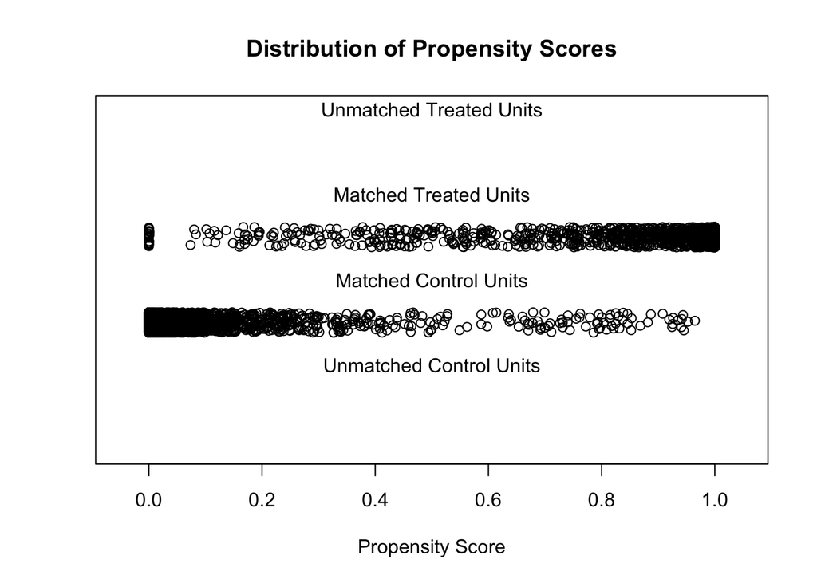

```r
plot(sem_pareamento, type = 'jitter', interactive = F)
```

#### 5.1.2.1 logit v2

```r
match_model_v2 <- matchit(tratamento ~
                    tx_maioridade +
                    tx_desemprego +
                    tx_clt +
                    tx_sem_carteita +
                    tx_conta_propria +
                    tx_empregador +
                    renda_media +
                    gini +
                    idhm +
                    va_agro +
                    va_ind +
                    va_serv +
                    pib_capita +
                    tx_rais_negativa +
                    tx_agro_extraca +
                    tx_ind_const +
                    tx_serv,
                    method = 'nearest', data = merged_psm,
                    distance = score_v2, ratio = 1,
                    discard = 'both')
```

```r
summary(match_model_v2)
```

```
##
## Call:
## matchit(formula = tratamento ~ tx_maioridade + tx_desemprego +
##     tx_clt + tx_sem_carteita + tx_conta_propria + tx_empregador +
##     renda_media + gini + idhm + va_agro + va_ind + va_serv +
##     pib_capita + tx_rais_negativa + tx_agro_extraca + tx_ind_const +
##     tx_serv, data = merged_psm, method = "nearest", distance = score_v2,
##     discard = "both", ratio = 1)
##
## Summary of Balance for All Data:
##                  Means Treated Means Control Std. Mean Diff. Var. Ratio
## distance                0.9045        0.0417          4.3004     3.1165
## tx_maioridade           0.7212        0.7339         -0.3981     0.8656
## tx_desemprego           0.0234        0.0578         -1.8926     0.6576
## tx_clt                  0.4075        0.5488         -0.8438     2.1572
## tx_sem_carteita         0.1191        0.1839         -1.4651     0.5360
## tx_conta_propria        0.3203        0.1807          1.1146     6.3960
## tx_empregador           0.0235        0.0184          0.3406     1.8545
## renda_media          1154.7037     1138.0706          0.0727     0.6873
## gini                    0.4406        0.4490         -0.1548     0.9320
## idhm                    0.7325        0.7395         -0.1757     1.5335
## va_agro                 0.2194        0.1657          0.3473     1.1613
## va_ind                  0.2307        0.2027          0.1894     0.9824
## va_serv                 0.3588        0.4302         -0.5709     0.8509
## pib_capita             29.5650       30.0001         -0.0283     0.2776
## tx_rais_negativa        0.5814        0.5791          0.0226     1.3359
## tx_agro_extraca         0.0621        0.1544         -0.9729     0.4474
## tx_ind_const            0.3515        0.2436          0.5562     1.1666
## tx_serv                 0.3938        0.4250         -0.1954     1.1223
##                  eCDF Mean eCDF Max
## distance            0.4875   0.9338
## tx_maioridade       0.0467   0.1772
## tx_desemprego       0.2026   0.6230
## tx_clt              0.1906   0.3761
## tx_sem_carteita     0.1702   0.4809
## tx_conta_propria    0.2363   0.5632
## tx_empregador       0.0618   0.2011
## renda_media         0.0659   0.1455
## gini                0.0250   0.0940
## idhm                0.0317   0.1111
```

[output cut: 40 more lines]

```
## va_agro             0.0107   0.0371          0.9845
## va_ind              0.0204   0.0943          1.1722
## va_serv             0.0286   0.1486          1.2393
## pib_capita          0.0623   0.1314          1.2644
## tx_rais_negativa    0.0131   0.0614          0.8412
## tx_agro_extraca     0.0514   0.2900          1.2257
## tx_ind_const        0.0385   0.0986          1.0515
## tx_serv             0.0318   0.1257          1.0238
##
## Sample Sizes:
##           Control Treated
## All          5128    2224
## Matched       700     700
## Unmatched    4370       0
## Discarded      58    1524
```

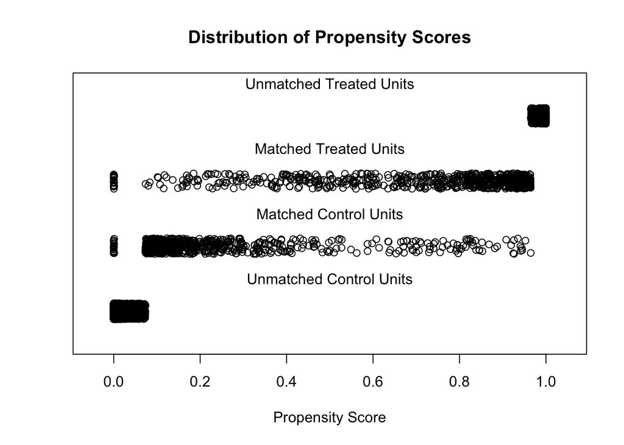

```r
plot(match_model_v2, type = 'jitter', interactive = F)
```

Façamos uma função para plotar o KDE, usando score externo ao pacote matchit:

```r
create_all_facets <- function(df, col){
  df$facet <- df[[col]]
  temp <- df
  temp$facet <- "all"
  merged <-rbind(temp, df)

  # ensure the facet value is a factor
  merged[[col]] <- as.factor(merged[[col]])

  return(merged)
}

plot_kde <- function(matched_df, scores) {
    df <- merged_psm %>%
        mutate(
            pareado = ifelse(id_ibge %in% matched_df$id_ibge, 'Pareado', 'Nao'),
            type = ifelse(tratamento == 1, 'Tratamento', 'Controle'),
            score = scores)

    new_df <- create_all_facets(df, 'pareado') %>%
        filter(facet != 'Nao')

    ggplot(data=new_df, aes(x=score)) +
        geom_histogram(aes(fill=type), alpha = 0.4)  +
        facet_wrap(~facet, scale = 'free') +
        theme(legend.position = "bottom")
}
```

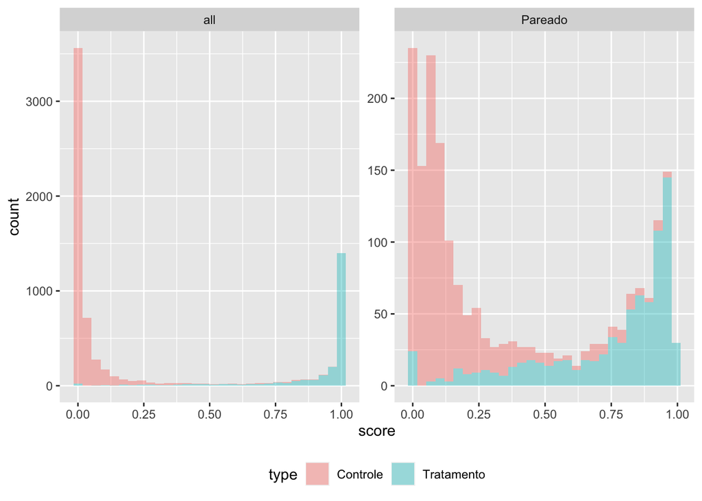

```r
plot_kde(match.data(match_model_v2), score_v2)
```

#### 5.1.2.2 logit v3

```r
score_v3 <- predict(logit_v3, type = 'response')
```

```r
match_model_v3 <- matchit(tratamento ~
                    tx_maioridade +
                    tx_desemprego +
                    tx_clt +
                    tx_sem_carteita +
                    renda_media +
                    gini +
                    tx_rais_negativa +
                    tx_agro_extraca +
                    tx_serv,
                    method = 'nearest', data = merged_psm,
                    distance = score_v3, ratio = 1,
                    discard = 'both')
```

```r
summary(match_model_v3)
```

```
##
## Call:
## matchit(formula = tratamento ~ tx_maioridade + tx_desemprego +
##     tx_clt + tx_sem_carteita + renda_media + gini + tx_rais_negativa +
##     tx_agro_extraca + tx_serv, data = merged_psm, method = "nearest",
##     distance = score_v3, discard = "both", ratio = 1)
##
## Summary of Balance for All Data:
##                  Means Treated Means Control Std. Mean Diff. Var. Ratio
## distance                0.8908        0.0475          3.8963     3.1588
## tx_maioridade           0.7212        0.7339         -0.3981     0.8656
## tx_desemprego           0.0234        0.0578         -1.8926     0.6576
## tx_clt                  0.4075        0.5488         -0.8438     2.1572
## tx_sem_carteita         0.1191        0.1839         -1.4651     0.5360
## renda_media          1154.7037     1138.0706          0.0727     0.6873
## gini                    0.4406        0.4490         -0.1548     0.9320
## tx_rais_negativa        0.5814        0.5791          0.0226     1.3359
## tx_agro_extraca         0.0621        0.1544         -0.9729     0.4474
## tx_serv                 0.3938        0.4250         -0.1954     1.1223
##                  eCDF Mean eCDF Max
## distance            0.4738   0.9202
## tx_maioridade       0.0467   0.1772
## tx_desemprego       0.2026   0.6230
## tx_clt              0.1906   0.3761
## tx_sem_carteita     0.1702   0.4809
## renda_media         0.0659   0.1455
## gini                0.0250   0.0940
## tx_rais_negativa    0.0266   0.0642
## tx_agro_extraca     0.1215   0.4064
## tx_serv             0.0365   0.1334
##
## Summary of Balance for Matched Data:
##                  Means Treated Means Control Std. Mean Diff. Var. Ratio
## distance                0.6308        0.2871          1.5882     1.3539
## tx_maioridade           0.7223        0.7259         -0.1145     1.0040
## tx_desemprego           0.0404        0.0455         -0.2764     1.4416
## tx_clt                  0.5268        0.5307         -0.0231     0.8564
## tx_sem_carteita         0.1412        0.1555         -0.3225     1.0963
## renda_media          1242.4415     1213.0930          0.1282     0.5041
## gini                    0.4537        0.4494          0.0792     0.7060
## tx_rais_negativa        0.5498        0.5577         -0.0792     0.6343
## tx_agro_extraca         0.0857        0.1160         -0.3189     1.1920
## tx_serv                 0.3960        0.3999         -0.0241     0.7846
##                  eCDF Mean eCDF Max Std. Pair Dist.
## distance            0.0524   0.5742          1.5882
## tx_maioridade       0.0199   0.1005          1.1743
## tx_desemprego       0.0371   0.1324          1.0643
## tx_clt              0.0220   0.0861          0.8065
## tx_sem_carteita     0.0420   0.1467          1.2870
## renda_media         0.0986   0.2026          1.4905
## gini                0.0243   0.1005          1.1079
## tx_rais_negativa    0.0250   0.1116          0.8124
## tx_agro_extraca     0.0475   0.3014          1.3344
## tx_serv             0.0262   0.0925          1.0056
##
## Sample Sizes:
##           Control Treated
## All          5128    2224
## Matched       627     627
## Unmatched    4457       0
## Discarded      44    1597
```

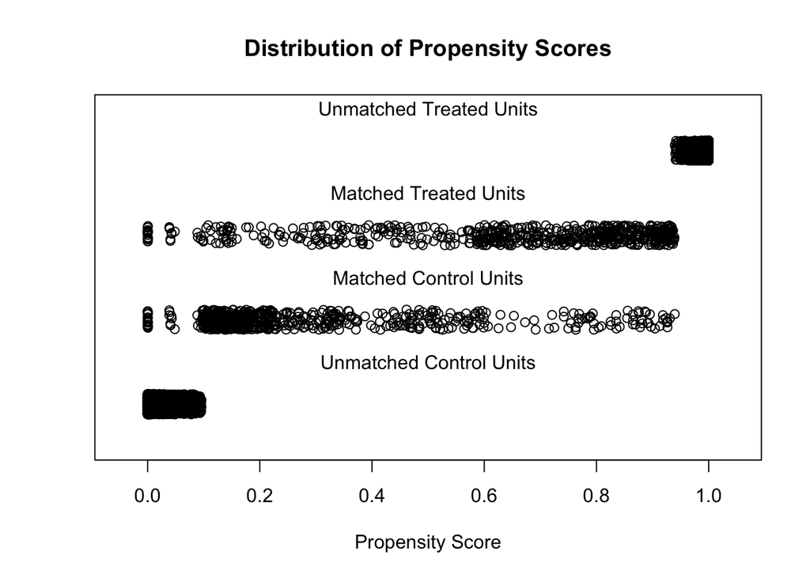

```r
plot(match_model_v3, type = 'jitter', interactive = F)
```

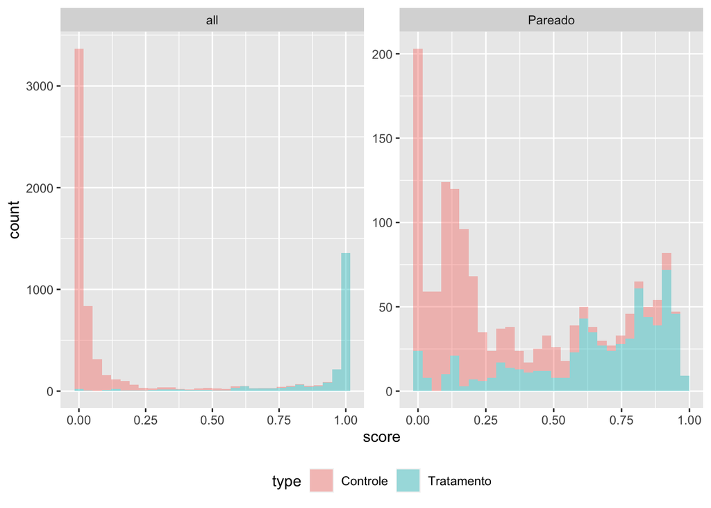

```r
plot_kde(match.data(match_model_v3), score_v3)
```

#### 5.1.2.3 Logit v4

```r
score_v4 <- predict(logit_v4, type = 'response')
```

```r
match_model_v4 <- matchit(tratamento ~
                    tx_maioridade +
                    tx_desemprego +
                    tx_clt +
                    tx_sem_carteita +
                    tx_rais_negativa +
                    tx_agro_extraca,
                    method = 'nearest', data = merged_psm,
                    distance = score_v4, ratio = 1,
                    discard = 'both')
```

```r
summary(match_model_v4)
```

```
##
## Call:
## matchit(formula = tratamento ~ tx_maioridade + tx_desemprego +
##     tx_clt + tx_sem_carteita + tx_rais_negativa + tx_agro_extraca,
##     data = merged_psm, method = "nearest", distance = score_v4,
##     discard = "both", ratio = 1)
##
## Summary of Balance for All Data:
##                  Means Treated Means Control Std. Mean Diff. Var. Ratio
## distance                0.8846        0.0502          3.8665     2.9986
## tx_maioridade           0.7212        0.7339         -0.3981     0.8656
## tx_desemprego           0.0234        0.0578         -1.8926     0.6576
## tx_clt                  0.4075        0.5488         -0.8438     2.1572
## tx_sem_carteita         0.1191        0.1839         -1.4651     0.5360
## tx_rais_negativa        0.5814        0.5791          0.0226     1.3359
## tx_agro_extraca         0.0621        0.1544         -0.9729     0.4474
##                  eCDF Mean eCDF Max
## distance            0.4491   0.9260
## tx_maioridade       0.0467   0.1772
## tx_desemprego       0.2026   0.6230
## tx_clt              0.1906   0.3761
## tx_sem_carteita     0.1702   0.4809
## tx_rais_negativa    0.0266   0.0642
## tx_agro_extraca     0.1215   0.4064
##
## Summary of Balance for Matched Data:
##                  Means Treated Means Control Std. Mean Diff. Var. Ratio
## distance                0.7276        0.2249          2.3290     1.4586
## tx_maioridade           0.7232        0.7281         -0.1521     0.9586
## tx_desemprego           0.0356        0.0475         -0.6554     1.2953
## tx_clt                  0.5197        0.5453         -0.1526     0.9992
## tx_sem_carteita         0.1353        0.1530         -0.4005     1.0091
## tx_rais_negativa        0.5451        0.5477         -0.0265     0.8690
## tx_agro_extraca         0.0727        0.1081         -0.3729     0.9558
##                  eCDF Mean eCDF Max Std. Pair Dist.
## distance            0.0840   0.7211          2.3290
## tx_maioridade       0.0205   0.0951          1.0779
## tx_desemprego       0.0762   0.3146          1.1288
## tx_clt              0.0387   0.1568          0.7627
## tx_sem_carteita     0.0494   0.1514          1.1843
## tx_rais_negativa    0.0144   0.0454          0.8414
## tx_agro_extraca     0.0499   0.2486          1.1609
##
## Sample Sizes:
##           Control Treated
## All          5128    2224
## Matched       925     925
## Unmatched    4143       0
## Discarded      60    1299
```

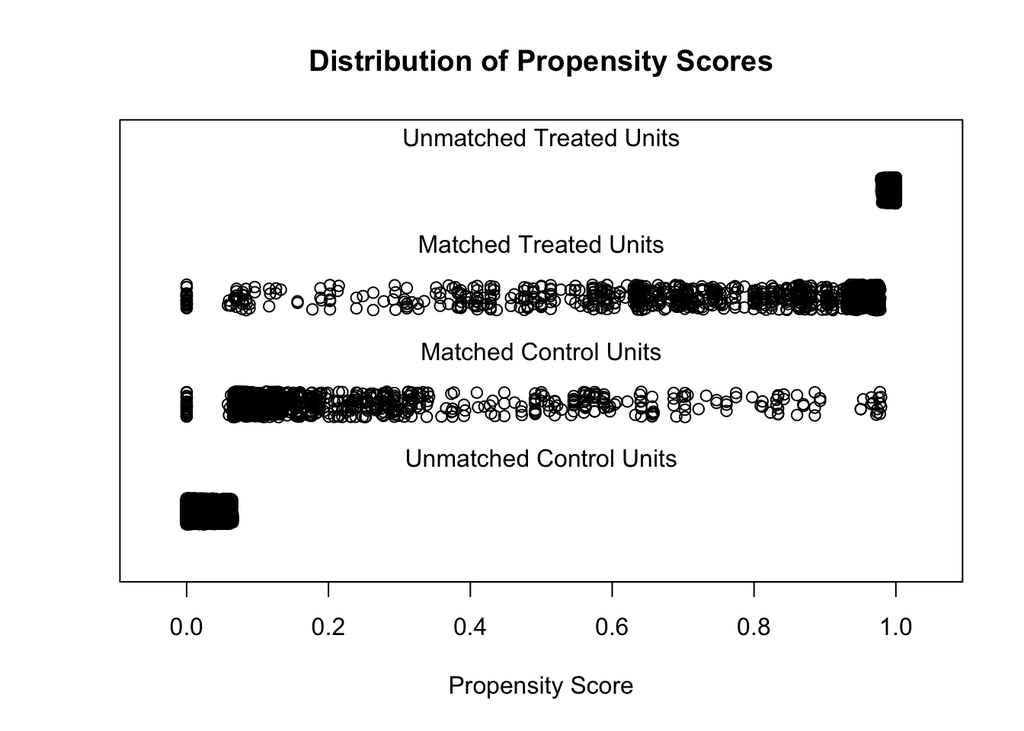

```r
plot(match_model_v4, type = 'jitter', interactive = F)
```

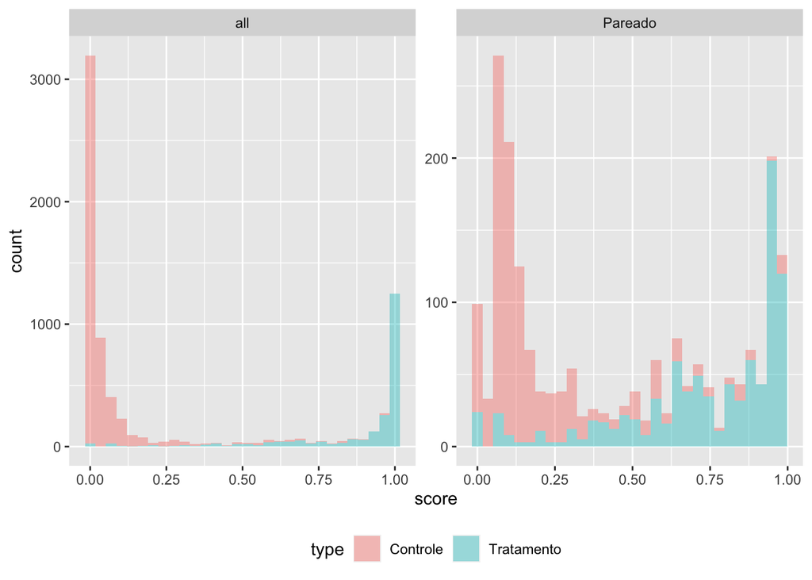

```r
plot_kde(match.data(match_model_v4), score_v4)
```

Nota-se que o pareamento não ficou muito próximo e excluiu vários municípios, apesar de ter melhorado o histoigrama e o balanceamento, na média.

## 5.2 Diferenças em diferenças

A última etapa é calcular o impacto médio do programa, tendo em vista que utilizaremos apenas municipios similares, em média, nas variáveis selecionadas, ou seja, foi possível um certo nível de balanceamento das covariadas.

### 5.2.1 Interpolação da PEA

O dado de PEA está disponível a nível municipal apenas via Censo. Como a variável de interesse é MEI / PEA, faz-se encessário estimar a PEA em 2019. Faremos isto utilizando a mesma taxa de cresscimento populacional, estimado pelo IBGE.

#### 5.2.1.1 Cálculo da taxa de crescimento da população

```r
pop_tx_cresc <- pop_estimada %>%
    pivot_wider(names_from = ano, values_from = valor, names_prefix = 'pop_')

head(pop_tx_cresc)
```

| uf | id_ibge | municipio | pop_2011 | pop_2019 |
| --- | --- | --- | --- | --- |
| SC | 4200051 | abdon batista | 2644 | 2563 |
| SC | 4200101 | abelardo luz | 17151 | 17904 |
| SC | 4200200 | agrolandia | 9440 | 10864 |
| SC | 4200309 | agronomica | 4954 | 5448 |
| SC | 4200408 | agua doce | 6971 | 7145 |
| SC | 4200507 | aguas de chapeco | 6136 | 6486 |

```r
pea_interpolada <- censo %>%
    select(c(uf, id_ibge, municipio, pea_maioridade, pop)) %>%
    rename(pop_2010 = pop, pea_2010 = pea_maioridade) %>%
    left_join(pop_tx_cresc) %>%
    mutate(
        tx_cresc_t1 = (pop_2011 - pop_2010) / pop_2010,
        tx_cresc_t2 = (pop_2019 - pop_2011) / pop_2011,
        pea_2011 = pea_2010 * (1 + tx_cresc_t1),
        pea_2019 = pea_2011 * (1 + tx_cresc_t2),
        across((starts_with('pea_')), ~round(.x,0))
    ) %>%
    select(-c(starts_with('pop'), starts_with('tx_'), pea_2010))
head(pea_interpolada)
```

| uf | id_ibge | municipio | pea_2011 | pea_2019 |
| --- | --- | --- | --- | --- |
| SC | 4200051 | abdon batista | 1072 | 1039 |
| SC | 4200101 | abelardo luz | 8188 | 8548 |
| SC | 4200200 | agrolandia | 5488 | 6316 |
| SC | 4200309 | agronomica | 2832 | 3114 |
| SC | 4200408 | agua doce | 3547 | 3636 |
| SC | 4200507 | aguas de chapeco | 3275 | 3462 |

```r
mei_cleaned <- mei %>%
    mutate(
        date = date %>%
            str_sub(-4,-1),
        qtd_mei = qtd_mei %>%
            str_replace_all('\\.', '') %>%
            as.numeric()
        ) %>%
    pivot_wider(names_from = date, values_from = qtd_mei, names_prefix = 'mei_')

head(mei_cleaned)
```

| uf | municipio | id_ibge | mei_2010 | mei_2011 | mei_2012 | mei_2013 | mei_2014 | mei_2015 | mei_2016 | mei_2017 | mei_2018 | mei_2019 |
| --- | --- | --- | --- | --- | --- | --- | --- | --- | --- | --- | --- | --- |
| SP | adamantina | 3500105 | 155 | 399 | 557 | 628 | 764 | 866 | 944 | 1078 | 1262 | 1547 |
| SP | adolfo | 3500204 | 8 | 31 | 56 | 95 | 122 | 159 | 184 | 211 | 213 | 255 |
| SP | aguai | 3500303 | 135 | 320 | 548 | 781 | 965 | 1158 | 1350 | 1570 | 1594 | 1817 |
| SP | aguas da prata | 3500402 | 17 | 49 | 88 | 118 | 147 | 177 | 214 | 288 | 323 | 412 |
| SP | aguas de lindoia | 3500501 | 69 | 179 | 330 | 522 | 717 | 947 | 1134 | 1406 | 1472 | 1654 |
| SP | aguas de santa barbara | 3500550 | 14 | 39 | 66 | 117 | 176 | 211 | 280 | 346 | 332 | 376 |

### 5.2.2 Base de dados para did

```r
base_did <- pea_interpolada %>%
    left_join(mei_cleaned) %>%
    mutate(
        tx_mei_2011 = mei_2011 / pea_2011 * 100,
        tx_mei_2019 = mei_2019 / pea_2019 * 100,
        tx_mei_2011 = tx_mei_2011 %>%
            round(2),
        tx_mei_2019 = tx_mei_2019 %>%
            round(2)) %>%
    select(-c(starts_with('mei_'), starts_with('pea_'))) %>%
    pivot_longer(cols = starts_with('tx_mei'), values_to = 'tx_mei') %>%
    mutate(
        tratamento = ifelse(uf == 'SC', 1, 0),
        periodo = ifelse(str_sub(name, -4, -1) == '2011', 0, 1),
        did = tratamento * periodo) %>%
    select(-c(name)) %>%
    relocate(c(uf, id_ibge, municipio, tx_mei, periodo, tratamento, did)) %>%
    left_join(merged_psm %>%
                  select(-c(4:17, ano)))
head(base_did)
```

| uf | id_ibge | municipio | tx_mei | periodo | tratamento | did | tx_maioridade | tx_dinheiro | tx_desemprego | tx_pea | tx_clt | tx_militar | tx_publico | tx_sem_carteita | tx_conta_propria | tx_empregador | renda_media | gini | idhm | va_agro | va_ind | va_serv | va_pub | pib_capita | tx_rais_negativa | tx_agro_extraca | tx_ind_const | tx_siup | tx_comercio | … |
| --- | --- | --- | --- | --- | --- | --- | --- | --- | --- | --- | --- | --- | --- | --- | --- | --- | --- | --- | --- | --- | --- | --- | --- | --- | --- | --- | --- | --- | --- | --- |
| SC | 4200051 | abdon batista | 1.77 | 0 | 1 | 0 | 0.73 | 0.91 | 0.01 | 0.56 | 0.15 | 0 | 0.08 | 0.15 | 0.5 | 0.03 | 883.92 | 0.45 | 0.69 | 0.39 | 0.13 | 0.26 | 0.22 | 18.40 | 0.74 | 0.00 | 0.01 | 0.02 | 0.17 | … |
| SC | 4200051 | abdon batista | 1.77 | 0 | 1 | 0 | 0.73 | 0.91 | 0.01 | 0.56 | 0.15 | 0 | 0.08 | 0.15 | 0.5 | 0.03 | 883.92 | 0.45 | 0.69 | 0.32 | 0.12 | 0.35 | 0.21 | 23.60 | 0.74 | 0.02 | 0.01 | 0.06 | 0.17 | … |
| SC | 4200051 | abdon batista | 1.77 | 0 | 1 | 0 | 0.73 | 0.91 | 0.01 | 0.56 | 0.15 | 0 | 0.08 | 0.15 | 0.5 | 0.03 | 883.92 | 0.45 | 0.69 | 0.40 | 0.11 | 0.27 | 0.22 | 24.82 | 0.74 | 0.00 | 0.19 | 0.03 | 0.20 | … |
| SC | 4200051 | abdon batista | 1.77 | 0 | 1 | 0 | 0.73 | 0.91 | 0.01 | 0.56 | 0.15 | 0 | 0.08 | 0.15 | 0.5 | 0.03 | 883.92 | 0.45 | 0.69 | 0.38 | 0.10 | 0.28 | 0.24 | 23.52 | 0.74 | 0.00 | 0.24 | 0.02 | 0.17 | … |
| SC | 4200051 | abdon batista | 1.77 | 0 | 1 | 0 | 0.73 | 0.91 | 0.01 | 0.56 | 0.15 | 0 | 0.08 | 0.15 | 0.5 | 0.03 | 883.92 | 0.45 | 0.69 | 0.34 | 0.07 | 0.31 | 0.27 | 23.79 | 0.74 | 0.00 | 0.28 | 0.02 | 0.31 | … |
| SC | 4200051 | abdon batista | 1.77 | 0 | 1 | 0 | 0.73 | 0.91 | 0.01 | 0.56 | 0.15 | 0 | 0.08 | 0.15 | 0.5 | 0.03 | 883.92 | 0.45 | 0.69 | 0.40 | 0.06 | 0.26 | 0.29 | 24.40 | 0.74 | 0.01 | 0.15 | 0.07 | 0.24 | … |

#### 5.2.2.1 Regressao com a base completa

```r
reg_completa_sem <- lm(tx_mei ~
                           tratamento + periodo + did,
                       data = base_did)
```

```r
summary(reg_completa_sem)
```

```
##
## Call:
## lm(formula = tx_mei ~ tratamento + periodo + did, data = base_did)
##
## Residuals:
##     Min      1Q  Median      3Q     Max
## -7.0025 -0.8325 -0.1722  0.6405 27.6675
##
## Coefficients:
##             Estimate Std. Error t value Pr(>|t|)
## (Intercept)  1.61223    0.02914  55.327   <2e-16 ***
## tratamento  -0.17276    0.05292  -3.265   0.0011 **
## periodo      8.52023    0.04121 206.749   <2e-16 ***
## did         -1.61058    0.07484 -21.521   <2e-16 ***
## ---
## Signif. codes:  0 '***' 0.001 '**' 0.01 '*' 0.05 '.' 0.1 ' ' 1
##
## Residual standard error: 2.086 on 14704 degrees of freedom
##   (34 observations deleted due to missingness)
## Multiple R-squared:  0.791,  Adjusted R-squared:  0.791
## F-statistic: 1.855e+04 on 3 and 14704 DF,  p-value: < 2.2e-16
```

```r
reg_completa_com <- lm(tx_mei ~
                           tratamento + periodo + did +
                           tx_maioridade +
                           tx_dinheiro +
                           tx_pea +
                           tx_clt +
                           tx_publico +
                           tx_empregador +
                           gini +
                           idhm +
                           va_agro +
                           va_ind +
                           tx_ind_const +
                           tx_serv,
                       data = base_did)
```

```r
summary(reg_completa_com)
```

```
##
## Call:
## lm(formula = tx_mei ~ tratamento + periodo + did + tx_maioridade +
##     tx_dinheiro + tx_pea + tx_clt + tx_publico + tx_empregador +
##     gini + idhm + va_agro + va_ind + tx_ind_const + tx_serv,
##     data = base_did)
##
## Residuals:
##     Min      1Q  Median      3Q     Max
## -6.3688 -0.9530 -0.1405  0.7176 25.0795
##
## Coefficients:
##                Estimate Std. Error t value Pr(>|t|)
## (Intercept)     9.37243    0.66906  14.008  < 2e-16 ***
## tratamento      0.37565    0.06053   6.206 5.59e-10 ***
## periodo         8.51917    0.03781 225.340  < 2e-16 ***
## did            -1.60379    0.06879 -23.315  < 2e-16 ***
## tx_maioridade -16.14569    0.69139 -23.353  < 2e-16 ***
## tx_dinheiro     4.81174    0.46842  10.272  < 2e-16 ***
## tx_pea         -8.28305    0.34195 -24.223  < 2e-16 ***
## tx_clt         -3.92891    0.19346 -20.309  < 2e-16 ***
## tx_publico     -4.68558    0.60936  -7.689 1.57e-14 ***
## tx_empregador  15.08482    1.61327   9.350  < 2e-16 ***
## gini           -2.37838    0.36631  -6.493 8.69e-11 ***
## idhm           12.76262    0.86775  14.708  < 2e-16 ***
## va_agro        -3.48013    0.16378 -21.249  < 2e-16 ***
## va_ind         -0.43333    0.16174  -2.679  0.00739 **
## tx_ind_const   -1.73981    0.15347 -11.337  < 2e-16 ***
## tx_serv        -0.77433    0.16886  -4.586 4.56e-06 ***
## ---
## Signif. codes:  0 '***' 0.001 '**' 0.01 '*' 0.05 '.' 0.1 ' ' 1
##
## Residual standard error: 1.913 on 14656 degrees of freedom
##   (70 observations deleted due to missingness)
## Multiple R-squared:  0.8245, Adjusted R-squared:  0.8243
## F-statistic:  4589 on 15 and 14656 DF,  p-value: < 2.2e-16
```

## 5.3 Regs com municipio pareado

```r
municipios_pareados <- base_did %>%
    filter(id_ibge %in% match.data(match_model_v3)$id_ibge)
```

```r
reg_amostra_sem <- lm(tx_mei ~
                          tratamento + periodo + did,
                      data = municipios_pareados)
```

```r
summary(reg_amostra_sem)
```

```
##
## Call:
## lm(formula = tx_mei ~ tratamento + periodo + did, data = municipios_pareados)
##
## Residuals:
##     Min      1Q  Median      3Q     Max
## -5.3717 -0.9517 -0.2439  0.6929 11.2763
##
## Coefficients:
##             Estimate Std. Error t value Pr(>|t|)
## (Intercept)  1.46079    0.07188  20.324   <2e-16 ***
## tratamento   0.23632    0.11073   2.134   0.0329 *
## periodo      8.34088    0.10165  82.057   <2e-16 ***
## did         -0.38425    0.15660  -2.454   0.0142 *
## ---
## Signif. codes:  0 '***' 0.001 '**' 0.01 '*' 0.05 '.' 0.1 ' ' 1
##
## Residual standard error: 2.171 on 3148 degrees of freedom
## Multiple R-squared:  0.7805, Adjusted R-squared:  0.7803
## F-statistic:  3732 on 3 and 3148 DF,  p-value: < 2.2e-16
```

```r
reg_amostra_com <- lm(tx_mei ~
                           tratamento + periodo + did +
                           tx_maioridade +
                           tx_pea +
                           tx_conta_propria +
                           gini +
                           idhm +
                           va_agro +
                           va_ind +
                           va_serv +
                           va_pub,
                       data = municipios_pareados)
summary(reg_amostra_com)
```

```
##
## Call:
## lm(formula = tx_mei ~ tratamento + periodo + did + tx_maioridade +
##     tx_pea + tx_conta_propria + gini + idhm + va_agro + va_ind +
##     va_serv + va_pub, data = municipios_pareados)
##
## Residuals:
##     Min      1Q  Median      3Q     Max
## -5.4573 -0.9806 -0.1194  0.8046  7.9632
##
## Coefficients:
##                   Estimate Std. Error t value Pr(>|t|)
## (Intercept)       13.44918    6.05892   2.220  0.02651 *
## tratamento         0.07097    0.10071   0.705  0.48103
## periodo            8.34088    0.08931  93.389  < 2e-16 ***
## did               -0.38425    0.13760  -2.793  0.00526 **
## tx_maioridade    -18.93501    1.46103 -12.960  < 2e-16 ***
## tx_pea           -11.05801    0.71884 -15.383  < 2e-16 ***
## tx_conta_propria   8.87713    0.64050  13.860  < 2e-16 ***
## gini              -5.51814    0.75204  -7.338 2.76e-13 ***
## idhm              17.72478    1.66911  10.619  < 2e-16 ***
## va_agro           -6.18743    5.97767  -1.035  0.30071
## va_ind            -5.19264    5.99259  -0.867  0.38628
## va_serv           -1.09636    5.97757  -0.183  0.85449
## va_pub            -2.40268    5.99396  -0.401  0.68856
## ---
## Signif. codes:  0 '***' 0.001 '**' 0.01 '*' 0.05 '.' 0.1 ' ' 1
##
## Residual standard error: 1.907 on 3139 degrees of freedom
## Multiple R-squared:  0.831,  Adjusted R-squared:  0.8304
## F-statistic:  1287 on 12 and 3139 DF,  p-value: < 2.2e-16
```